# Prosper Loan Data

## Introduction

> This data set contains 113,937 loans with 81 variables on each loan, including loan amount, borrower rate (or interest rate), current loan status, borrower income, and many others.

## Preliminary Wrangling

```python
# import all packages and set plots to be embedded inline
import numpy as np
import pandas as pd
import matplotlib.pyplot as plt
import seaborn as sb

%matplotlib inline
```

> Load in your dataset and describe its properties through the questions below. Try and motivate your exploration goals through this section.

```python
#Load dataset into pandas dataframe
Loan_df= pd.read_csv('prosperLoanData.csv')
Loan_df.head(10)
```

|  | ListingKey | ListingNumber | ListingCreationDate | CreditGrade | Term | LoanStatus | ClosedDate | BorrowerAPR | BorrowerRate | LenderYield | ... | LP_ServiceFees | LP_CollectionFees | LP_GrossPrincipalLoss | LP_NetPrincipalLoss | LP_NonPrincipalRecoverypayments | PercentFunded | Recommendations | InvestmentFromFriendsCount | InvestmentFromFriendsAmount | Investors |
| --- | --- | --- | --- | --- | --- | --- | --- | --- | --- | --- | --- | --- | --- | --- | --- | --- | --- | --- | --- | --- | --- |
| 0 | 1021339766868145413AB3B | 193129 | 2007-08-26 19:09:29.263000000 | C | 36 | Completed | 2009-08-14 00:00:00 | 0.16516 | 0.1580 | 0.1380 | ... | -133.18 | 0.0 | 0.0 | 0.0 | 0.0 | 1.0 | 0 | 0 | 0.0 | 258 |
| 1 | 10273602499503308B223C1 | 1209647 | 2014-02-27 08:28:07.900000000 | NaN | 36 | Current | NaN | 0.12016 | 0.0920 | 0.0820 | ... | 0.00 | 0.0 | 0.0 | 0.0 | 0.0 | 1.0 | 0 | 0 | 0.0 | 1 |
| 2 | 0EE9337825851032864889A | 81716 | 2007-01-05 15:00:47.090000000 | HR | 36 | Completed | 2009-12-17 00:00:00 | 0.28269 | 0.2750 | 0.2400 | ... | -24.20 | 0.0 | 0.0 | 0.0 | 0.0 | 1.0 | 0 | 0 | 0.0 | 41 |
| 3 | 0EF5356002482715299901A | 658116 | 2012-10-22 11:02:35.010000000 | NaN | 36 | Current | NaN | 0.12528 | 0.0974 | 0.0874 | ... | -108.01 | 0.0 | 0.0 | 0.0 | 0.0 | 1.0 | 0 | 0 | 0.0 | 158 |
| 4 | 0F023589499656230C5E3E2 | 909464 | 2013-09-14 18:38:39.097000000 | NaN | 36 | Current | NaN | 0.24614 | 0.2085 | 0.1985 | ... | -60.27 | 0.0 | 0.0 | 0.0 | 0.0 | 1.0 | 0 | 0 | 0.0 | 20 |
| 5 | 0F05359734824199381F61D | 1074836 | 2013-12-14 08:26:37.093000000 | NaN | 60 | Current | NaN | 0.15425 | 0.1314 | 0.1214 | ... | -25.33 | 0.0 | 0.0 | 0.0 | 0.0 | 1.0 | 0 | 0 | 0.0 | 1 |
| 6 | 0F0A3576754255009D63151 | 750899 | 2013-04-12 09:52:56.147000000 | NaN | 36 | Current | NaN | 0.31032 | 0.2712 | 0.2612 | ... | -22.95 | 0.0 | 0.0 | 0.0 | 0.0 | 1.0 | 0 | 0 | 0.0 | 1 |
| 7 | 0F1035772717087366F9EA7 | 768193 | 2013-05-05 06:49:27.493000000 | NaN | 36 | Current | NaN | 0.23939 | 0.2019 | 0.1919 | ... | -69.21 | 0.0 | 0.0 | 0.0 | 0.0 | 1.0 | 0 | 0 | 0.0 | 1 |
| 8 | 0F043596202561788EA13D5 | 1023355 | 2013-12-02 10:43:39.117000000 | NaN | 36 | Current | NaN | 0.07620 | 0.0629 | 0.0529 | ... | -16.77 | 0.0 | 0.0 | 0.0 | 0.0 | 1.0 | 0 | 0 | 0.0 | 1 |
| 9 | 0F043596202561788EA13D5 | 1023355 | 2013-12-02 10:43:39.117000000 | NaN | 36 | Current | NaN | 0.07620 | 0.0629 | 0.0529 | ... | -16.77 | 0.0 | 0.0 | 0.0 | 0.0 | 1.0 | 0 | 0 | 0.0 | 1 |

10 rows × 81 columns

```python
#number of rows and columns in the dataset
print(f"There are {Loan_df.shape[0]} rows and {Loan_df.shape[1]} columns in the Prosper Loan dataset.")
```

```
There are 113937 rows and 81 columns in the Prosper Loan dataset.
```

```python
Loan_df.info()
```

```
<class 'pandas.core.frame.DataFrame'>
RangeIndex: 113937 entries, 0 to 113936
Data columns (total 81 columns):
 #   Column                               Non-Null Count   Dtype
---  ------                               --------------   -----
 0   ListingKey                           113937 non-null  object
 1   ListingNumber                        113937 non-null  int64
 2   ListingCreationDate                  113937 non-null  object
 3   CreditGrade                          28953 non-null   object
 4   Term                                 113937 non-null  int64
 5   LoanStatus                           113937 non-null  object
 6   ClosedDate                           55089 non-null   object
 7   BorrowerAPR                          113912 non-null  float64
 8   BorrowerRate                         113937 non-null  float64
 9   LenderYield                          113937 non-null  float64
```

[output cut: 73 more lines]

```python
#copy the original data
Rating = Loan_df.copy()

#filter to where Prosper Ratings were not specified which is for pre-July 2009 loans
Rating = Rating[Rating['ProsperRating (Alpha)'].isnull()]
```

```python
#fill the null ProsperRating with the rating in CreditGrade
Rating['ProsperRating (Alpha)']= Rating['CreditGrade']
```

```python
#assign the populated ProsperRating to the original df
mask= Loan_df['ProsperRating (Alpha)'].isnull()
column_name = ['ProsperRating (Alpha)']
Loan_df.loc[mask, column_name] = Rating
```

```python
#confirm the populated ProsperRating has been assigned to the original df
Loan_df['ProsperRating (Alpha)'].value_counts()
```

```
C     23994
B     19970
D     19427
A     17866
E     13084
HR    10443
AA     8881
NC      141
Name: ProsperRating (Alpha), dtype: int64
```

```python
#replace NC rating with NaN as the rating is not used by ProsperLoan
Loan_df['ProsperRating (Alpha)'] = Loan_df['ProsperRating (Alpha)'].replace('NC', np.NaN)
```

```python
#drop columns where more than 75% of the data are null values
Loan_df.drop(['CreditGrade','GroupKey','TotalProsperLoans','TotalProsperPaymentsBilled','OnTimeProsperPayments',
                'ProsperPaymentsLessThanOneMonthLate','ProsperPaymentsOneMonthPlusLate','ProsperPrincipalBorrowed',
               'ProsperPrincipalOutstanding','ScorexChangeAtTimeOfListing','LoanFirstDefaultedCycleNumber'],axis =1,inplace = True)
```

```python
#data types of dataset
Loan_df.dtypes
```

```
ListingKey                      object
ListingNumber                    int64
ListingCreationDate             object
Term                             int64
LoanStatus                      object
                                ...
PercentFunded                  float64
Recommendations                  int64
InvestmentFromFriendsCount       int64
InvestmentFromFriendsAmount    float64
Investors                        int64
Length: 70, dtype: object
```

```python
# descriptive statistics for numeric variables
Loan_df.describe(include = 'all')
```

|  | ListingKey | ListingNumber | ListingCreationDate | Term | LoanStatus | ClosedDate | BorrowerAPR | BorrowerRate | LenderYield | EstimatedEffectiveYield | ... | LP_ServiceFees | LP_CollectionFees | LP_GrossPrincipalLoss | LP_NetPrincipalLoss | LP_NonPrincipalRecoverypayments | PercentFunded | Recommendations | InvestmentFromFriendsCount | InvestmentFromFriendsAmount | Investors |
| --- | --- | --- | --- | --- | --- | --- | --- | --- | --- | --- | --- | --- | --- | --- | --- | --- | --- | --- | --- | --- | --- |
| count | 113937 | 1.139370e+05 | 113937 | 113937.000000 | 113937 | 55089 | 113912.000000 | 113937.000000 | 113937.000000 | 84853.000000 | ... | 113937.000000 | 113937.000000 | 113937.000000 | 113937.000000 | 113937.000000 | 113937.000000 | 113937.000000 | 113937.000000 | 113937.000000 | 113937.000000 |
| unique | 113066 | NaN | 113064 | NaN | 12 | 2802 | NaN | NaN | NaN | NaN | ... | NaN | NaN | NaN | NaN | NaN | NaN | NaN | NaN | NaN | NaN |
| top | 17A93590655669644DB4C06 | NaN | 2013-10-02 17:20:16.550000000 | NaN | Current | 2014-03-04 00:00:00 | NaN | NaN | NaN | NaN | ... | NaN | NaN | NaN | NaN | NaN | NaN | NaN | NaN | NaN | NaN |
| freq | 6 | NaN | 6 | NaN | 56576 | 105 | NaN | NaN | NaN | NaN | ... | NaN | NaN | NaN | NaN | NaN | NaN | NaN | NaN | NaN | NaN |
| mean | NaN | 6.278857e+05 | NaN | 40.830248 | NaN | NaN | 0.218828 | 0.192764 | 0.182701 | 0.168661 | ... | -54.725641 | -14.242698 | 700.446342 | 681.420499 | 25.142686 | 0.998584 | 0.048027 | 0.023460 | 16.550751 | 80.475228 |
| std | NaN | 3.280762e+05 | NaN | 10.436212 | NaN | NaN | 0.080364 | 0.074818 | 0.074516 | 0.068467 | ... | 60.675425 | 109.232758 | 2388.513831 | 2357.167068 | 275.657937 | 0.017919 | 0.332353 | 0.232412 | 294.545422 | 103.239020 |
| min | NaN | 4.000000e+00 | NaN | 12.000000 | NaN | NaN | 0.006530 | 0.000000 | -0.010000 | -0.182700 | ... | -664.870000 | -9274.750000 | -94.200000 | -954.550000 | 0.000000 | 0.700000 | 0.000000 | 0.000000 | 0.000000 | 1.000000 |
| 25% | NaN | 4.009190e+05 | NaN | 36.000000 | NaN | NaN | 0.156290 | 0.134000 | 0.124200 | 0.115670 | ... | -73.180000 | 0.000000 | 0.000000 | 0.000000 | 0.000000 | 1.000000 | 0.000000 | 0.000000 | 0.000000 | 2.000000 |
| 50% | NaN | 6.005540e+05 | NaN | 36.000000 | NaN | NaN | 0.209760 | 0.184000 | 0.173000 | 0.161500 | ... | -34.440000 | 0.000000 | 0.000000 | 0.000000 | 0.000000 | 1.000000 | 0.000000 | 0.000000 | 0.000000 | 44.000000 |
| 75% | NaN | 8.926340e+05 | NaN | 36.000000 | NaN | NaN | 0.283810 | 0.250000 | 0.240000 | 0.224300 | ... | -13.920000 | 0.000000 | 0.000000 | 0.000000 | 0.000000 | 1.000000 | 0.000000 | 0.000000 | 0.000000 | 115.000000 |
| max | NaN | 1.255725e+06 | NaN | 60.000000 | NaN | NaN | 0.512290 | 0.497500 | 0.492500 | 0.319900 | ... | 32.060000 | 0.000000 | 25000.000000 | 25000.000000 | 21117.900000 | 1.012500 | 39.000000 | 33.000000 | 25000.000000 | 1189.000000 |

11 rows × 70 columns

```python
Loan_df.duplicated().sum()
```

```
0
```

### What is the structure of your dataset?

> There are 113,937 loans in the dataset with 81 variables (Term, LoanStatus, BorrowerAPR, BorrowerRate, ListingKey, ListingNumber, etc). Most of the variables are numeric in nature, but variables such as Term, LoanStatus, ProsperScore, ProsperRating, ListingCategory, BorrowerState, Occupation etc. are categorical variables.

### What is/are the main feature(s) of interest in your dataset?

> I am interested in finding out the features that affect the BorrowerRate.

### What features in the dataset do you think will help support your investigation into your feature(s) of interest?

> I expect that the LoanOriginalAmount will have some effect on the BorrowerRate: The higher the LoanOriginalAmount, the higher the BorrowerRate. I also think that other variables such as: LoanOriginalAmount, StatedMonthlyIncome, Term, ProsperRating (Alpha), EmploymentStatus, LoanCurrentDaysDelinquent, and MonthlyLoanPayment will have effects on the BorrowerRate.

```python
#select columns (features) relevant to loan data exploration
Loan_df = Loan_df[['BorrowerRate','BorrowerAPR','LoanOriginalAmount','StatedMonthlyIncome','Term','ProsperRating (Alpha)',
                     'EmploymentStatus', 'LoanCurrentDaysDelinquent','MonthlyLoanPayment']]
Loan_df.info()
```

[output not shown]

## Univariate Exploration

**I will start by looking at the distribution of the main variable of interest: `BorrowerRate` (Interest Rate)**

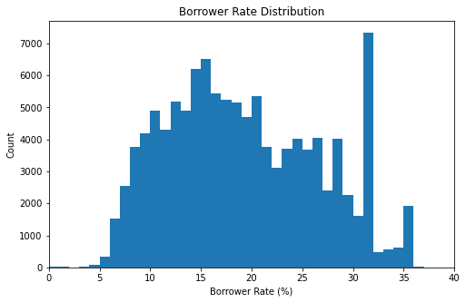

```python
InterestRate= Loan_df['BorrowerRate'] * 100
bins = np.arange(0, Loan_df.BorrowerRate.max()*100 +1, 1)
plt.figure(figsize=[8, 5])
plt.hist(x = InterestRate, bins = bins)
plt.xlabel('Borrower Rate (%)')
plt.ylabel('Count')
plt.title('Borrower Rate Distribution')
plt.xlim(0,40);
```

> The interest rate distribution looks roughly multimodal, with one peak at 16%, a very high peak at 32%, and a small peak at 36%.

**The next distribution to look at is the first predictor variable of interest: `BorrowerAPR`**

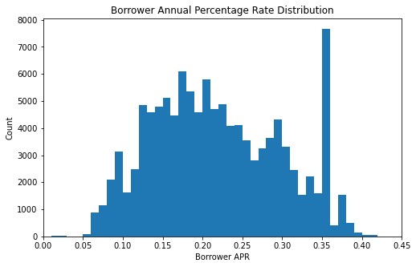

```python
bins = np.arange(0, Loan_df.BorrowerAPR.max()+0.01, 0.01)
plt.figure(figsize=[8, 5])
plt.hist(data = Loan_df, x = 'BorrowerAPR', bins = bins);
plt.xlabel('Borrower APR')
plt.ylabel('Count')
plt.title('Borrower Annual Percentage Rate Distribution')
plt.xlim(0,0.45);
```

The Borrower Annual Percentage Rate distribution is roughly multimodal with one peak at 0.10, another at 0.18, another peak at 0.30, the highest peak at 0.36 and a small peak at 0.38.

**The next distribution to look at is the `LoanOriginalAmount`**

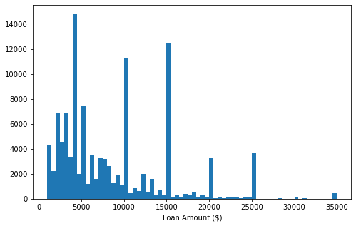

```python
bins = np.arange(1000, Loan_df.LoanOriginalAmount.max()+500, 500)
plt.figure(figsize=[8, 5])
plt.hist(data = Loan_df, x = 'LoanOriginalAmount', bins = bins)
plt.xlabel('Loan Amount ($)');
```

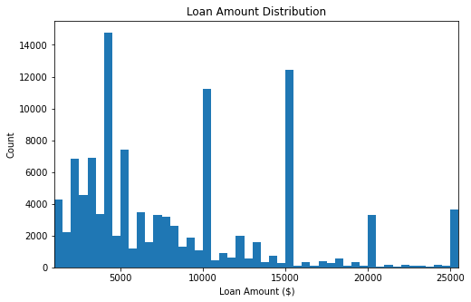

```python
#investigating further by limiting the x axis
bins = np.arange(1000, Loan_df.LoanOriginalAmount.max()+500, 500)
plt.figure(figsize=[8, 5])
plt.hist(data = Loan_df, x = 'LoanOriginalAmount', bins = bins)
plt.xlabel('Loan Amount ($)')
plt.xlim(1000, 25500)
plt.ylabel('Count')
plt.title('Loan Amount Distribution');
```

**I will be looking at the distribution of `StatedMonthlyIncome`**

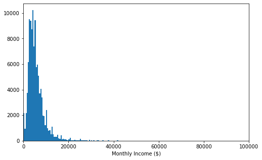

```python
bins = np.arange(0, Loan_df.StatedMonthlyIncome.max()+500, 500)
plt.figure(figsize=[8, 5])
plt.hist(data = Loan_df, x = 'StatedMonthlyIncome', bins = bins)
plt.xlabel('Monthly Income ($)')
plt.xlim(0, 100000);
```

```python
Loan_df['StatedMonthlyIncome'].describe()
```

```
count    1.139370e+05
mean     5.608026e+03
std      7.478497e+03
min      0.000000e+00
25%      3.200333e+03
50%      4.666667e+03
75%      6.825000e+03
max      1.750003e+06
Name: StatedMonthlyIncome, dtype: float64
```

```python
Outliers = (Loan_df['StatedMonthlyIncome'] > 60000)

print(Outliers.sum())
print(Loan_df.loc[Outliers,['BorrowerRate','LoanOriginalAmount', 'StatedMonthlyIncome','Term']])
```

```
66
        BorrowerRate  LoanOriginalAmount  StatedMonthlyIncome  Term
4691          0.0974               13000         75000.000000    36
8066          0.3199                2000        416666.666667    36
8870          0.1200               12500        208333.333333    36
11312         0.0800                3000         75000.000000    36
13039         0.1559               10000         83333.333333    36
...              ...                 ...                  ...   ...
104834        0.1764               15000         70833.333333    36
105248        0.1685               25000         70833.333333    36
109043        0.1459               25000         68750.000000    36
111265        0.1819               12765        108750.000000    60
113270        0.1899                2000        394400.000000    36

[66 rows x 4 columns]
```

> There might have been an error in data input. Interestingly, these loans tend to be low when compared against the borrowed loan amount.

```python
#remove outliers in monthly income
Loan_df = Loan_df.loc[-Outliers,:]
```

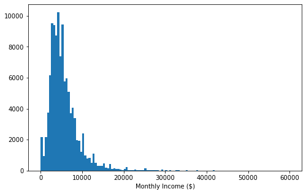

```python
bins = np.arange(0, Loan_df.StatedMonthlyIncome.max()+500, 500)
plt.figure(figsize=[8, 5])
plt.hist(data = Loan_df, x = 'StatedMonthlyIncome', bins = bins)
plt.xlabel('Monthly Income ($)');
```

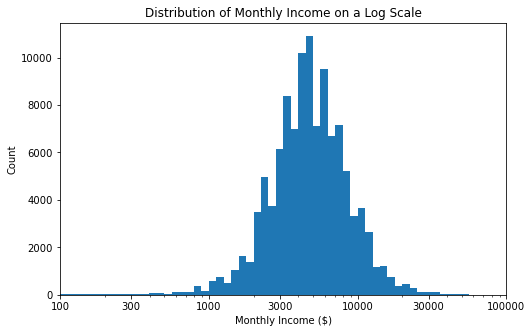

```python
#the distribution is skewed to the right so let's use a logarithmic transformation
bins = 10 ** np.arange(0, 15 + 0.05, 0.05)
plt.figure(figsize=[8, 5])
plt.hist(data = Loan_df, x = 'StatedMonthlyIncome', bins = bins)
plt.xscale('log')
ticks= [100, 300, 1000, 3000, 10000, 30000, 100000]
labels= [format (t) for t in ticks]
plt.xlim(100,100000)
plt.xticks(ticks, labels)
plt.xlabel('Monthly Income ($)')
plt.ylabel('Count')
plt.title('Distribution of Monthly Income on a Log Scale');
```

> The stated monthly income shows a unimodal distribution with the highest peaks in monthly income ranging from 4000 dollars to 6000 dollars.

**I will be exploring other variables in the dataset such as: `Term`, `ProsperRating (Alpha)`, and `EmploymentStatus`**

```python
# Convert ProsperRating (Alpha) to ordered categorical types
ProsperRate= ['HR','E','D','C','B','A','AA']
Ordered_ProsperRate = pd.api.types.CategoricalDtype(ordered = True,
                                    categories = ProsperRate)
Loan_df['ProsperRating (Alpha)'] = Loan_df['ProsperRating (Alpha)'].astype(Ordered_ProsperRate)
```

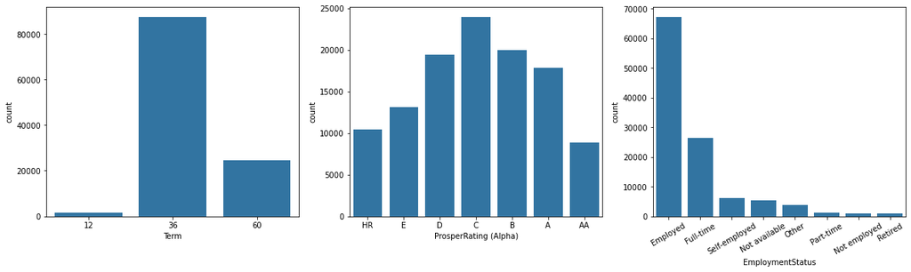

```python
#plot categorical variables together to get an idea of each variable's distribution
plt.figure(figsize = [20,5])
color = sb.color_palette()[0]
plt.subplot(1,3,1)
sb.countplot(data = Loan_df, x = 'Term', color = color)

plt.subplot(1,3,2)
sb.countplot(data = Loan_df, x = 'ProsperRating (Alpha)', color = color)

plt.subplot(1,3,3)
desc_order= Loan_df.EmploymentStatus.value_counts().index
sb.countplot(data = Loan_df, x = 'EmploymentStatus', order= desc_order, color = color)
plt.xticks(rotation=30);
```

> Prosper loans have three loan tenures which are 12 months, 36 months and 60 months with most of the borrowers opting for the 36 months tenured loan. Majority of the borrowers have a Prosper credit rating of C with the least number of borrowers having a very good credit rating of AA. Majority of the borrowers are Employed or Full-time staff

**Another distribution that would be explored is the `LoanCurrentDaysDelinquent`**

```python
#group LoanCurrentDaysDelinquent into categories
bin_edges=[0,1,31,61,91,121,181,2705]
bin_names= ['Ongoing', 'Past Due(1-30 Days)', 'Past Due(31-60 Days)', 'Past Due(61-90 Days)',
            'Past Due(91-120 Days)', 'Past Due(121-180 Days)', 'Past Due(>180 Days)']
Loan_df['DelinquentBucket'] = pd.cut(Loan_df['LoanCurrentDaysDelinquent'], bin_edges, labels=bin_names, right = False)
```

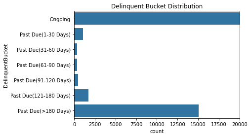

```python
#plot delinquent bucket
sb.countplot(data= Loan_df, y = 'DelinquentBucket', color = color)
plt.xlim(0,20000)
plt.title('Delinquent Bucket Distribution');
```

> Asides from borrowers whose loan term is ongoing, a very large number of borrowers tend to fall within the delinquent bucket of Past Due (>180 Days) which is 6 months or more.

**The final variable of interest to be explored is the `MonthlyLoanPayment`**

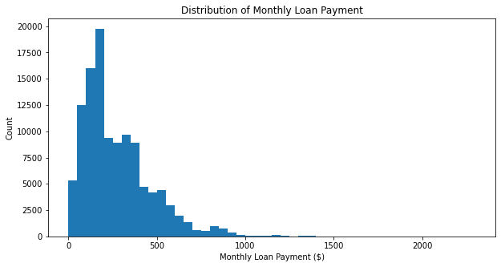

```python
bins = np.arange(0, Loan_df.MonthlyLoanPayment.max()+50, 50)
plt.figure(figsize=[10, 5])
plt.hist(data = Loan_df, x = 'MonthlyLoanPayment', bins = bins)
plt.xlabel('Monthly Loan Payment ($)')
plt.ylabel('Count')
plt.title('Distribution of Monthly Loan Payment');
#plt.xlim(0, 1400);
```

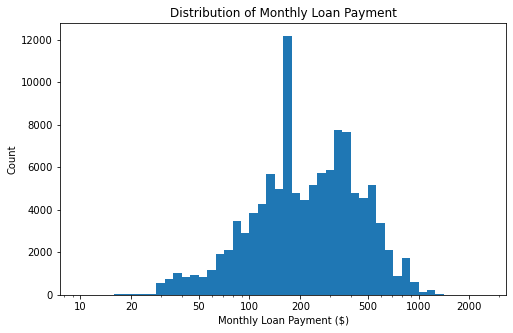

```python
#the distribution is skewed to the right so let's use a logarithmic transformation
bins = 10 ** np.arange(1, np.log10(Loan_df['MonthlyLoanPayment'].max()) + 0.05, 0.05)
plt.figure(figsize=[8, 5])
plt.hist(data = Loan_df, x = 'MonthlyLoanPayment', bins = bins)
plt.xscale('log')
plt.xticks([10, 20, 50, 100, 200, 500, 1000, 2000], [10, 20, 50, 100, 200, 500, 1000, 2000])
plt.xlabel('Monthly Loan Payment ($)')
plt.ylabel('Count')
plt.title('Distribution of Monthly Loan Payment')
plt.show();
```

> The distribution shows that most borrowers tend to pay between 100 and 200 dollars as monthly loan payments. And also between 300 and 400 dollars.

### Discuss the distribution(s) of your variable(s) of interest. Were there any unusual points? Did you need to perform any transformations?

> Stated Monthly Income and Monthly Loan Payment were transformed using a log scale to interprete the distribution because they were right skewed. The transformation showed that most borrowers monthly income was within the range of \$4000 to \\$6000. Most borrowers tend to pay between \$100 and \\$400 as monthly loan payments for their loans.

## Bivariate Exploration

**To start off with, I want to look at the pairwise correlations present between features in the data.**

```python
#categorize qualitative and quantitative variables to view correlation and select the right charts
quantitative= ['BorrowerRate', 'BorrowerAPR', 'LoanOriginalAmount', 'StatedMonthlyIncome', 'LoanCurrentDaysDelinquent',
               'MonthlyLoanPayment']

qualitative = ['Term', 'ProsperRating (Alpha)', 'EmploymentStatus', 'DelinquentBucket']
```

[figure not shown]

```python
# correlation plot of qualitative variables
plt.figure(figsize = [8, 6])
sb.heatmap(Loan_df[quantitative].corr(), annot = True, fmt = '.3f',
           cmap = 'vlag_r', center = 0)
plt.show()
```

[figure not shown]

```python
# plot matrix: sample 1000 Prosper loans so that plots are clearer and can render faster
samples = np.random.choice(Loan_df.shape[0], 1000, replace = False)
Loan_df_samp = Loan_df.loc[samples,:]

g = sb.PairGrid(data = Loan_df_samp, vars = quantitative)
g = g.map_diag(plt.hist, bins = 15);
g.map_offdiag(plt.scatter);
```

> There is a positive correlation between the `BorrowerRate` and `BorrowerAPR`. The correlation coefficient of `BorrowerAPR` and `LoanOriginalAmount` is **-0.323**, the scatter plot also shows that these two variables are negatively correlated. The `LoanOriginalAmount` is positively correlated with the `StatedMonthlyIncome`, it makes sense because the higher your income the higher the loan amount. The correlation coefficient between `MonthlyLoanPayment` and `LoanOriginalAmount`is **0.932** and this shows that there is a positive correlation because the higher the loan borrowed the higher the monthly loan payment.

**Let's move on to looking at how BorrowerRate, StatedMonthlyIncome, and LoanOriginalAmount correlate with the categorical variables.**

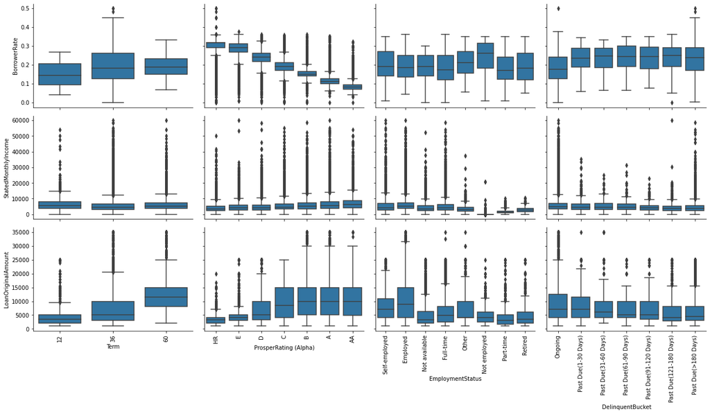

```python
def boxgrid(x, y, **kwargs):
    sb.boxplot(x, y, color = color)

plt.figure(figsize = [20, 20])
g = sb.PairGrid(data = Loan_df, y_vars = ['BorrowerRate', 'StatedMonthlyIncome', 'LoanOriginalAmount'],
                x_vars = qualitative, height = 3, aspect = 1.5)
g.map(boxgrid)
for ax in g.axes.flatten():
    ax.tick_params(axis= 'x', rotation = 90)
plt.show();
```

> The visualization shows that the loan amount is increased with the increase of loan term. The BorrowerRate decreases as borrowers have better credit rating. Borrowers with the best Prosper ratings have the lowest BorrowerRate. This indicates Prosper rating has a strong effect on BorrowerRate. Borrowers with better rating also have higher monthly income and loan amount. Borrowers that are Employed, Self-employed and Full time have more monthly income and loan amount than others.

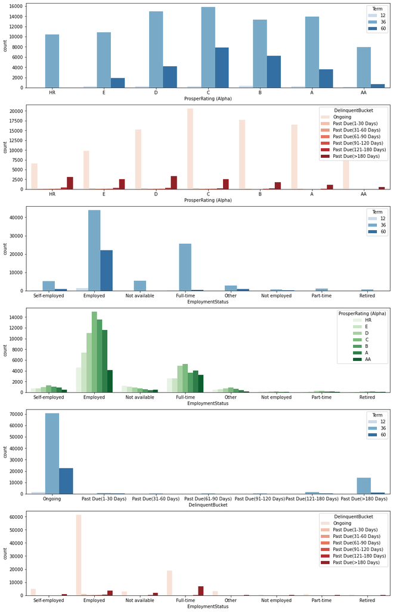

```python
plt.figure(figsize = [15, 25])

#subplot 1: ProsperRating (Alpha) vs Term
plt.subplot(6, 1, 1)
sb.countplot(data = Loan_df, x = 'ProsperRating (Alpha)', hue = 'Term', palette = 'Blues')

#subplot 2: ProsperRating (Alpha) vs DelinquentBucket
plt.subplot(6, 1, 2)
sb.countplot(data = Loan_df, x = 'ProsperRating (Alpha)', hue = 'DelinquentBucket', palette = 'Reds')

#subplot 3: EmploymentStatus vs Term
plt.subplot(6, 1, 3)
sb.countplot(data = Loan_df, x = 'EmploymentStatus', hue = 'Term', palette = 'Blues')
#plt.xticks(rotation=10)

#subplot 4: ProsperRating (Alpha) vs EmploymentStatus, use different color palette
plt.subplot(6, 1, 4)
sb.countplot(data = Loan_df, x = 'EmploymentStatus', hue = 'ProsperRating (Alpha)', palette = 'Greens')

#subplot 5: DelinquentBucket vs Term
plt.subplot(6, 1, 5)
sb.countplot(data = Loan_df, x = 'DelinquentBucket', hue = 'Term', palette = 'Blues')

#subplot 6: EmploymentStatus vs DelinquentBucket, use different color palette
plt.subplot(6, 1, 6)
sb.countplot(data = Loan_df, x = 'EmploymentStatus', hue = 'DelinquentBucket', palette = 'Reds');
```

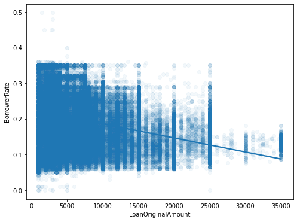

```python
plt.figure(figsize = [8, 6])
sb.regplot(data = Loan_df, x = 'LoanOriginalAmount', y = 'BorrowerRate', scatter_kws={'alpha':0.05});
```

> This plot shows that the BorrowerRate decreases as the LoanOriginalAmount increases. This indicates a negative correlation between the BorrowerRate and LoanOriginalAmount.

### Talk about some of the relationships you observed in this part of the investigation. How did the feature(s) of interest vary with other features in the dataset?

> There is a negative correlation between the BorrowerRate and LoanOriginalAmount, which means the higher the loan amount, the lower the BorrowerRate. Borrowers with the best Prosper ratings have the lowest BorrowerRate. This indicates Prosper rating has a strong effect on BorrowerRate. Borrowers with better rating also have higher monthly income and loan amount.

## Multivariate Exploration

> The main thing I want to explore in this part of the analysis is how the qualitative variables (Prosper rating, DelinquentBucket, and term) play into the relationship between BorrowerRate and LoanOriginalAamount.

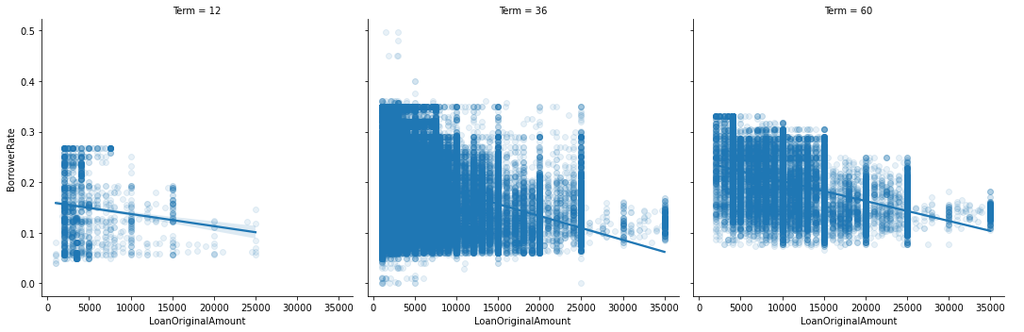

```python
# Term relation with BorrowerRate and LoanOriginalAmount
g=sb.FacetGrid(data=Loan_df, aspect=1, height=5, col='Term')
g.map(sb.regplot, 'LoanOriginalAmount', 'BorrowerRate', x_jitter=0.04, scatter_kws={'alpha':0.1});
g.add_legend();
```

> The plot shows that term does not have an effect on the interaction between the BorrowerRate and LoanOriginalAmount

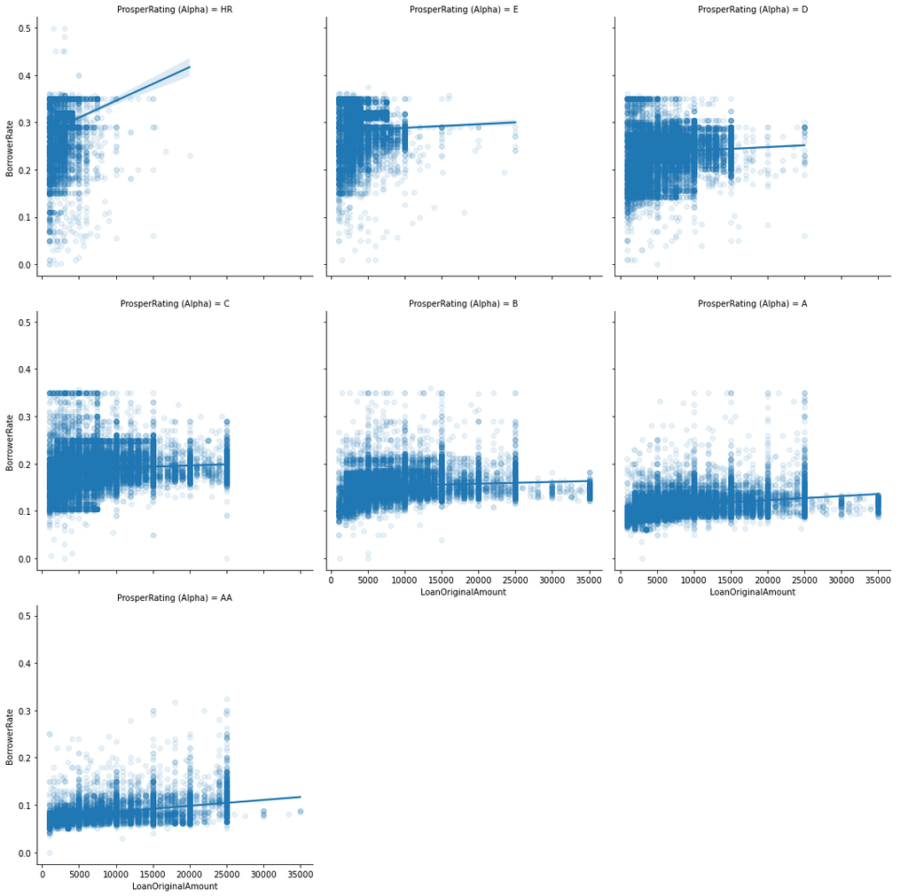

```python
# ProsperRating (Alpha) relation with BorrowerRate and LoanOriginalAmount
g=sb.FacetGrid(data=Loan_df, aspect=1, height=5, col='ProsperRating (Alpha)', col_wrap=3)
g.map(sb.regplot, 'LoanOriginalAmount', 'BorrowerRate', x_jitter=0.04, scatter_kws={'alpha':0.1});
g.add_legend();
```

> The LoanOriginalAmount increases as the ProsperRating (Alpha) becomes better. The BorrowerRate gradually decreases as the credit rating gets better.

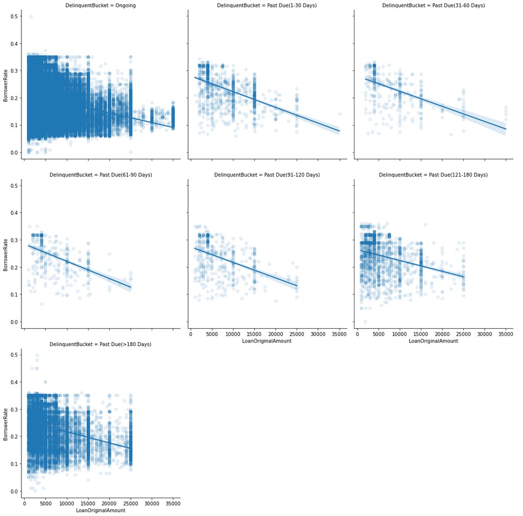

```python
# DelinquentBucket relation with BorrowerRate and LoanOriginalAmount
g=sb.FacetGrid(data=Loan_df, aspect=1, height=5, col='DelinquentBucket', col_wrap=3)
g.map(sb.regplot, 'LoanOriginalAmount', 'BorrowerRate', x_jitter=0.04, scatter_kws={'alpha':0.1});
g.add_legend();
```

> The LoanOriginalAmount reduces as the DelinquencyBucket increases and gets to a fixed amount of 25000. The frequency and range of the BorrowerRate increases as the DelinquencyBucket increases.

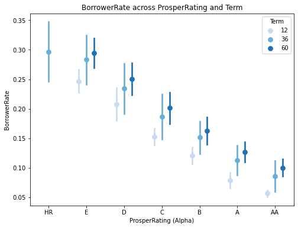

```python
plt.figure(figsize = [8,6])
sb.pointplot(data = Loan_df, x = 'ProsperRating (Alpha)', y = 'BorrowerRate', hue = 'Term',
           palette = 'Blues', linestyles = '', dodge = 0.4, ci='sd')
plt.title('BorrowerRate across ProsperRating and Term')
plt.ylabel('BorrowerRate');
```

> The BorrowerRate decreases as the ProsperRating gets better. Interestingly, 60 month tenured loans generally have higher BorrowerRate than other tenured loans as the Rating gets better except for the HR rating where the BorrowerRate is the highest with only the 36 month termed loan.

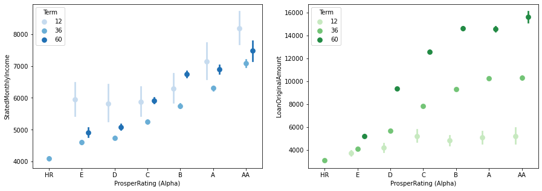

```python
plt.figure(figsize=[15,5])

plt.subplot(1,2,1)
sb.pointplot(data = Loan_df, x = 'ProsperRating (Alpha)', y = 'StatedMonthlyIncome', hue = 'Term',
           palette = 'Blues', linestyles = '', dodge = 0.4);

plt.subplot(1,2,2)
sb.pointplot(data = Loan_df, x = 'ProsperRating (Alpha)', y = 'LoanOriginalAmount', hue = 'Term',
           palette = 'Greens', linestyles = '', dodge = 0.4);
```

> The plot shows that there is no clear effect between Term and ProsperRating on the StatedMonthlyIncome. In the case of the LoanOriginalAmount, there is an effect between the Term and ProsperRating. As the ProsperRating gets higher, there is an increase in the LoanOriginalAmount across the termed loans.

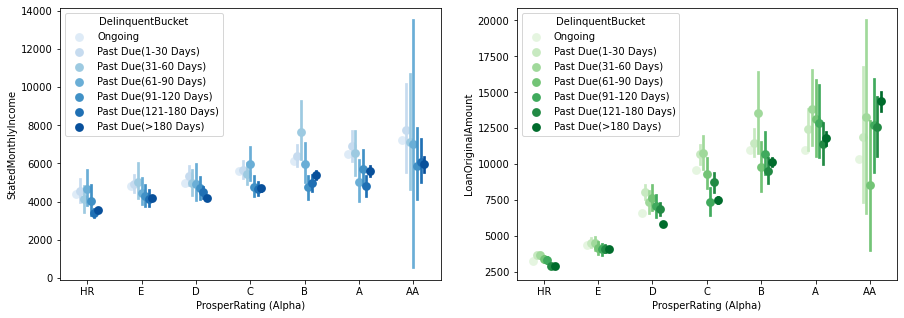

```python
plt.figure(figsize=[15,5])
plt.subplot(1,2,1)
sb.pointplot(data = Loan_df, x = 'ProsperRating (Alpha)', y = 'StatedMonthlyIncome', hue = 'DelinquentBucket',
           palette = 'Blues', linestyles = '', dodge = 0.4);

plt.subplot(1,2,2)
sb.pointplot(data = Loan_df, x = 'ProsperRating (Alpha)', y = 'LoanOriginalAmount', hue = 'DelinquentBucket',
           palette = 'Greens', linestyles = '', dodge = 0.4);
```

> The plot shows that DelinquentBucket does not have an effect on the interaction between the ProsperRating (Alpha) and StatedMonthlyIncome and the interaction between ProsperRating (Alpha) and LoanOriginalAmount.

### Talk about some of the relationships you observed in this part of the investigation. Were there features that strengthened each other in terms of looking at your feature(s) of interest?

> I extended my investigation of BorrowerRate against LoanOriginalAmount by looking at the effect of the ProsperRating (Alpha). The multivariate exploration showed that the LoanOriginalAmount increases as the ProsperRating (Alpha) becomes higher and the BorrowerRate gradually decreases as the credit rating gets better. I also explored the ProsperRating (Alpha) and Term effects on the LoanOriginalAmount. It revealed that as the ProsperRating gets higher, there is an increase in the LoanOriginalAmount across the termed loans.

### Were there any interesting or surprising interactions between features?

> An interesting interaction is the decrease in BorrowerRate as the ProsperRating gets better. Also, 60 month tenured loans generally have higher BorrowerRate that other tenured loans as the Rating gets better except for the HR rating where the BorrowerRate is the highest with only the 36 month termed loan.

## Conclusions

> Stated Monthly Income and Monthly Loan Payment were transformed using a log scale to interprete the distribution because they were right skewed. The transformation showed that most borrowers monthly income was within the range of \$4000 to \\$6000. Most borrowers tend to pay between \$100 and \\$400 as monthly loan payments for their loans.

> There is a negative correlation between the BorrowerRate and LoanOriginalAmount, which means the higher the loan amount, the lower the BorrowerRate. Borrowers with the best Prosper ratings have the lowest BorrowerRate. This indicates Prosper rating has a strong effect on BorrowerRate. Borrowers with better rating also have higher monthly income and loan amount.